# Titanic Survival Part 1: Exploratory Data Analysis

### 11 Survived and Age

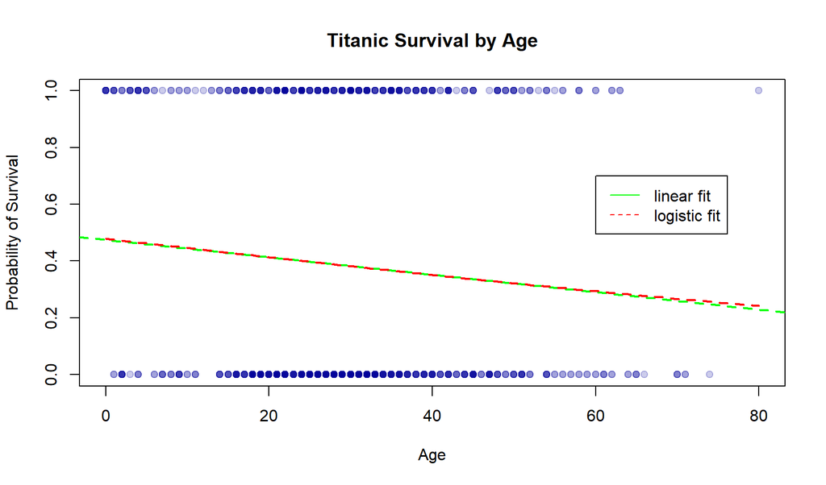

```r
# 11 Survived & Age
plot(train$SurvivedNum~train$AgeNum, pch=19, col=rgb(0,0,.6,.2),
    main="Titanic Survival by Age",ylab="Probability of Survival", xlab="Age")
linmod=lm(SurvivedNum~AgeNum,data=train)
abline(linmod, col="green", lwd=2, lty=2)
g=glm(SurvivedNum~AgeNum,family='binomial',data=train)
curve(predict(g,data.frame(AgeNum=x),type="resp"),col="red",lty=2,lwd=2,add=TRUE)
legend(60,0.7,c("linear fit","logistic fit"), col=c("green","red"), lty=c(1,2))
```

The linear correlation coefficient shows this mild negative association with age:

```r
cor(train$SurvivedNum,train$AgeNum)
```

```
## [1] -0.08554137
```

We see some evidence in the training sample that the probability of survival declines with age, and since the probabilities observed are not extreme (survival was not rare and the distribution of age is near normal) the linear fit almost coincides with the logistic (sinusoidal) fit. Another way to visualize this is to plot the two categorical versions of these two same variables.

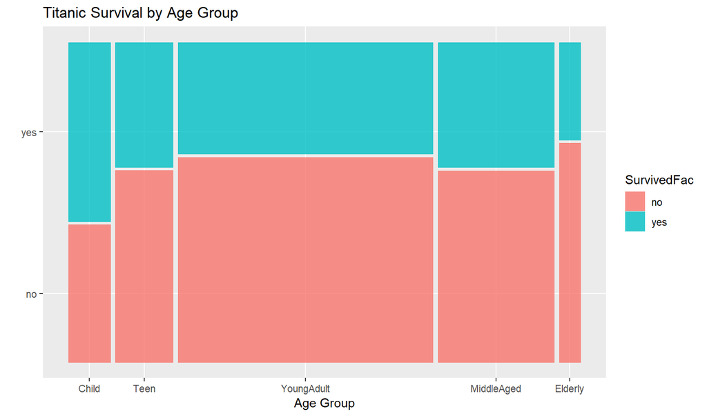

```r
# 11 Survived & Age as Factor
ggplot(data=train) +
   geom_mosaic(aes(x=product(SurvivedFac, AgeFac),fill=SurvivedFac)) +
   labs(x='Age Group', y='', title='Titanic Survival by Age Group')
```

# Multivariate Graphical EDA

```r
# Combinations of 3 or more variables quickly explode
vars <- 1:12
for (i in 2:10) {
    num <- length(combn(vars,i))/i
    print(paste("There are ", num, "combinations of 12 variables taken", i, "at a time."))
}
```

```
## [1] "There are  66 combinations of 12 variables taken 2 at a time."
## [1] "There are  220 combinations of 12 variables taken 3 at a time."
## [1] "There are  495 combinations of 12 variables taken 4 at a time."
## [1] "There are  792 combinations of 12 variables taken 5 at a time."
## [1] "There are  924 combinations of 12 variables taken 6 at a time."
## [1] "There are  792 combinations of 12 variables taken 7 at a time."
## [1] "There are  495 combinations of 12 variables taken 8 at a time."
## [1] "There are  220 combinations of 12 variables taken 9 at a time."
## [1] "There are  66 combinations of 12 variables taken 10 at a time."
```

The number of combinations is complementary (adding up to 12), so when considering combinations of 10 variables, we are just considering the complement of 2 variables, and so forth.

There are clearly too many trivariate combinations to consider even if we stick with those that interact with `Survival`, so we stick with just a few hunches and questions we might have about the data.

We noted earlier that it would be interesting to explore whether men survived more in groups or alone, and whether children of wealthier classes survived more than children of poorer classes, or whether men of higher classes survived worse (or better?) than children in poorer classes, and so forth.

## Are single men better at saving themselves?

We informally hypothesize that family men might lose their place at a lifeboat more by prioritizing their families, while single men have less incentive to save women and children. We can do some quick plots to see whether the data seems to confirm this.

It is good to visualize proportions of subsamples to check whether any subgroups are underrepresented and notice how the subgroups relate to each other.

I’ve created an `IsSingle` variable just for this purpose, which assumes that if a person had zero relatives they were “single”, or alone, at least in the Titanic voyage.

```r
# creating IsSingle variable
train$IsSingle <- ifelse(train$NumRelatives==0,1,0)
train$IsSingle <- factor(train$IsSingle, levels=0:1, labels=c("Not Single","Single"))
```

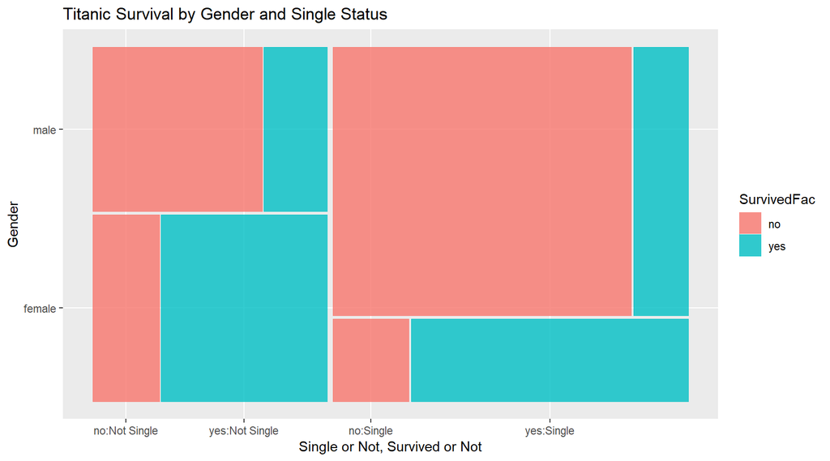

```r
ggplot(data=train) +
   geom_mosaic(aes(x=product(GenderFac, IsSingle),fill=SurvivedFac)) +
   labs(x='Single or Not, Survived or Not', y='Gender',
   title='Titanic Survival by Gender and Single Status')
```

This mosaic plot shows how the majority were alone but within that majority, a vast majority were male, and within that specific subgroup (male, single), the greatest majority died, so our hypothesis is not sounding that great, it would see as though being a single male was not a good indicator of survivability. It is a bit hard to compare the proportions of only males, and a confounding factor is `Age` so we can get a fuller picture by plotting only the male population as far as their age, single status and survivability.

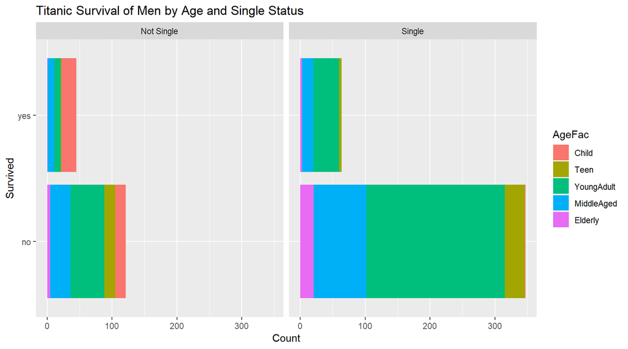

```r
ggplot(data=train) +
   geom_bar(aes(x=SurvivedFac,y=IsMale,fill=AgeFac), stat="identity") +
   facet_wrap(aes(IsSingle))+
           coord_flip() +
   labs(x='Survived', y='Count',
   title='Titanic Survival of Men by Age and Single Status')
```

The vast majority of children were not alone, and of the great number of single males that did not survive, there were quite a number of elderly (the majority of that age group) men. We now wonder how women survived as far as age groups and single status.

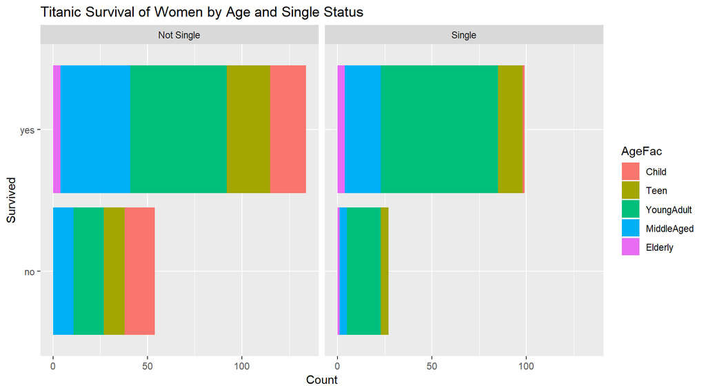

```r
# Women by Age and Single Status
ggplot(data=train) +
   geom_bar(aes(x=SurvivedFac,y=-(IsMale-1),fill=AgeFac), stat="identity") +
   facet_wrap(aes(IsSingle))+
           coord_flip() +
   labs(x='Survived', y='Count',
   title='Titanic Survival of Women by Age and Single Status')
```

I got curious and wanted to see who were these children with no relatives in the Titanic:

```r
chosen <- c("PclassFac","GenderFac","NumRelatives","TicketCount","AgeNum","SurvivedFac")
train[,colnames(train) %in% chosen][train$AgeFac=="Child" & train$NumRelatives == 0,]
```

```
##     PclassFac GenderFac NumRelatives TicketCount AgeNum SurvivedFac
## 732 3rd Class      male            0           2     11          no
## 778 3rd Class    female            0           2      5         yes
```

In our training sample there are just two seemingly unaccompanied children, both in 3rd Class: a 5-year old girl who survived and an 11-year old boy who did not. They appear to have no relatives yet the ticket count is 2. An assumption could be made that this was some kind of error and these children were accompanied by family.

## How does age, passenger class and gender relate to survivability?

One motivating question could be: *“Do children in third class survive less than adults in first class?”*

Below are thee panel plots, one for each passenger class, split by gender (panels), age group (bars) and survival (color). Patterns emerge:

So it is true that children of third class survived less than adults in first class, except for males taken alone. Note that the scale of the third class is much higher (400s) than that of the first two classes.

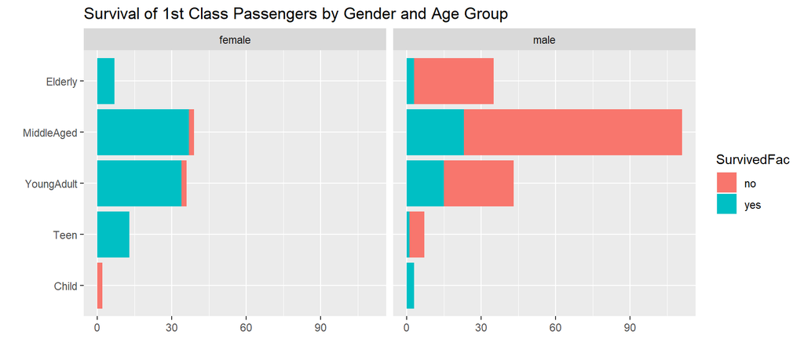

```r
# Survival of 1st Class Passengers by Gender and Age Group
ggplot(data=train[train$PclassNum==1,]) +
   geom_bar(aes(x=AgeFac,y=-(SurvivedNum-2), fill=SurvivedFac), stat="identity") +
   facet_wrap(aes(GenderFac)) +
   labs(x='', y='',
   title='Survival of 1st Class Passengers by Gender and Age Group') +
   coord_flip()
```

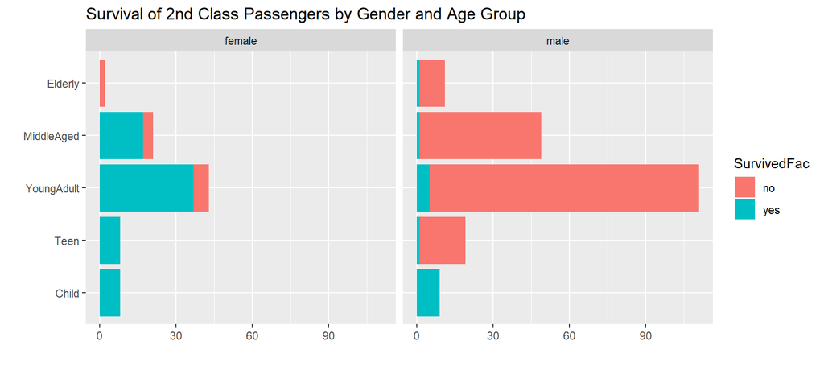

```r
# Survival of 2nd Class Passengers by Gender and Age Group
ggplot(data=train[train$PclassNum==2,]) +
   geom_bar(aes(x=AgeFac,y=-(SurvivedNum-2), fill=SurvivedFac), stat="identity") +
   facet_wrap(aes(GenderFac))+
   labs(x='', y='',
   title='Survival of 2nd Class Passengers by Gender and Age Group') +
   coord_flip()
```

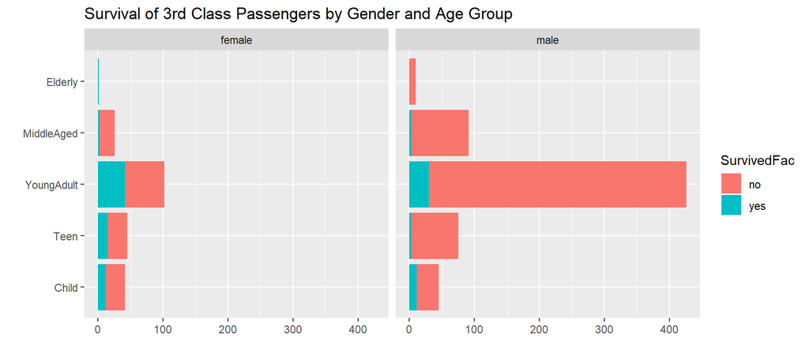

```r
# Survival of 3rd Class Passengers by Gender and Age Group
ggplot(data=train[train$PclassNum==3,]) +
   geom_bar(aes(x=AgeFac,y=-(SurvivedNum-2), fill=SurvivedFac), stat="identity") +
   facet_wrap(aes(GenderFac))+
   labs(x='', y='',
   title='Survival of 3rd Class Passengers by Gender and Age Group') +
   coord_flip()
```

If you were a male in the Titanic, the best chances of survival would be if you were:

1. a child not in third class
2. a first class young adult
3. a first class middle aged adult

The best chances for survival overall are if you were a female not in third class.

Too detailed patterns, such as how the only clear cut gender/survival division happened in the third class elderly age group, where all males died and all females survived, are probably not real insightful patterns but more due to random noise fluctuations in the sample.

# Conclusion

While one might be tempted to keep exploring multivariate combinations of features ad nausem, it would be more useful and agile to start building machine-learning models and trying out some predictions and come back for further exploratory data analysis later, as per the iterative approach to data science described in the overview.

Some of the patterns we uncovered during this exploration might be helpful when **feature engineering** during **modeling pre-processing**, which I will be doing in a Jupyter Notebook in Python.

Here is a distilled summary of our data analysis process, a to-do list for the modeling phase:

- keep `PassengerID` (need it for the competition submission file)
- `Name`: extract titles with regex, create `Title`
- `Name`: extract length, create `NameLength`
- drop `Name`
- create `NumRelatives`
- create `TicketCount`
- create `FarePerPerson` using `TicketCount`
- drop `Fare`
- drop `Ticket`
- extract cabin letters from `Cabin` (regex)
- impute two missing vals in `Embarked` with the majority class
- impute `Age` with a random forest model

Here is the number of **binary indicators (dummies)** that we will consider:

- `Title`: 4 dummies
- `Cabin`: 5 dummies
- `Embarked`: 2 dummies
- `Sex`: 1 dummy
- `Pclass`: 2 dummies
- `Age`: numeric or 4 dummies

Since the number of dummies is relatively small, we do not need to use *label embedding* or *binary encoding*.

**Extra variables** we might consider creating depending on the model include:

- `SingleFem`, `SingleMale`: since a confounder of Single is Gender
- `IsMaleMiddleAged`: or variants, including `Not1stClass`

Modeling will inform us as to whether it helps at all to bundle characteristis into a single variable (and drop the originals) or whether the mix of original variabes already capture these characteristics enough.

We will also consider **scaling** depending on the modeling strategy.